# CNP Nutrition Signature Validation

*Panel:* Vitamin E · *Training set:* GSE110747 liver · mouse vitamin E diet · *Signature size:* 11 genes · *Score direction learned in training:* GSVA lower in case; ssGSEA higher in case; PLAGE lower in case; zScore lower in case; singscore lower in case

| Dataset | Species | Signature genes | Found in data | Coverage |
| --- | --- | --- | --- | --- |
| GSE110747 liver · mouse vitamin E diet | Mus musculus | 11 | 9 | 82% |
| GSE1063 · rat vitamin E-deficient diet | Rattus norvegicus | 11 | 1 | 9% |
| GSE8150 brain · aged mouse tocopherol | Mus musculus | 11 | 9 | 82% |
| GSE8146 heart · aged mouse tocopherol | Mus musculus | 11 | 7 | 64% |
| GSE195619 HepaRG · human oleic acid ± vitamin E | Homo sapiens | 11 | 9 | 82% |

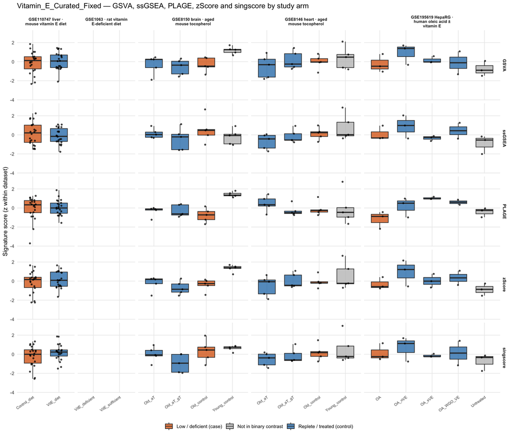

**ANOVA p-values.** *All arms* = one-way ANOVA across every study arm; *case vs control* = group effect after the listed covariates.

| Dataset | Role | Adjusted for | p (all arms) / p (case vs control) GSVA | p (all arms) / p (case vs control) ssGSEA | p (all arms) / p (case vs control) PLAGE | p (all arms) / p (case vs control) zScore | p (all arms) / p (case vs control) singscore |
| --- | --- | --- | --- | --- | --- | --- | --- |
| GSE110747 liver · mouse vitamin E diet | Training | exercise | 0.642 / 0.646 | 0.457 / 0.462 | 0.803 / 0.805 | 0.354 / 0.358 | 0.166 / 0.166 |
| GSE1063 · rat vitamin E-deficient diet | External | — | — / — | — / — | — / — | — / — | — / — |
| GSE8150 brain · aged mouse tocopherol | External | — | 0.009 / 0.776 | 0.474 / 0.261 | 6.7e-05 / 0.196 | 5.1e-04 / 0.873 | 0.053 / 0.174 |
| GSE8146 heart · aged mouse tocopherol | External | — | 0.577 / 0.767 | 0.131 / 0.184 | 0.715 / 0.674 | 0.454 / 0.710 | 0.391 / 0.212 |
| GSE195619 HepaRG · human oleic acid ± vitamin E | External | — | 0.370 / 0.376 | 0.238 / 0.741 | 0.030 / 0.007 | 0.245 / 0.265 | 0.591 / 0.888 |

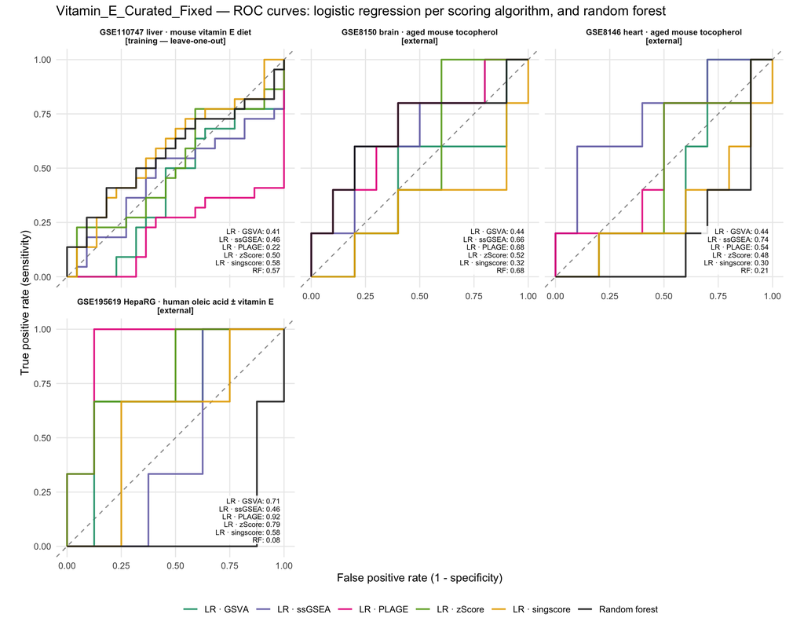

| Dataset | Validation | Model | AUC | 95% CI | Accuracy (p ≥ 0.5) | n case | n control |
| --- | --- | --- | --- | --- | --- | --- | --- |
| GSE110747 liver · mouse vitamin E diet | Internal (in-sample) | Score · GSVA | 0.53 | 0.36–0.71 | — | 22 | 22 |
|  |  | Score · ssGSEA | 0.55 | 0.37–0.72 | — | 22 | 22 |
|  |  | Score · PLAGE | 0.45 | 0.27–0.63 | — | 22 | 22 |
|  |  | Score · zScore | 0.55 | 0.37–0.72 | — | 22 | 22 |
|  |  | Score · singscore | 0.60 | 0.43–0.77 | — | 22 | 22 |
|  | Internal (LOOCV) | LR · GSVA | 0.41 | 0.24–0.58 | 0.52 | 22 | 22 |
|  |  | LR · ssGSEA | 0.46 | 0.28–0.64 | 0.57 | 22 | 22 |
|  |  | LR · PLAGE | 0.22 | 0.08–0.36 | 0.34 | 22 | 22 |
|  |  | LR · zScore | 0.50 | 0.33–0.68 | 0.48 | 22 | 22 |
|  |  | LR · singscore | 0.58 | 0.41–0.76 | 0.55 | 22 | 22 |
|  |  | Random forest | 0.57 | 0.40–0.75 | 0.57 | 22 | 22 |
|  | Internal (leave-pair-out) | LR · GSVA | 0.52 | — | — | 22 | 22 |
|  |  | LR · ssGSEA | 0.55 | — | — | 22 | 22 |
|  |  | LR · PLAGE | 0.34 | — | — | 22 | 22 |
|  |  | LR · zScore | 0.55 | — | — | 22 | 22 |
|  |  | LR · singscore | 0.60 | — | — | 22 | 22 |
|  |  | Random forest | 0.59 | — | — | 22 | 22 |
| GSE8150 brain · aged mouse tocopherol | External | Score · GSVA | 0.44 | 0.09–0.79 | — | 5 | 10 |
|  |  | Score · ssGSEA | 0.66 | 0.33–0.99 | — | 5 | 10 |
|  |  | Score · PLAGE | 0.68 | 0.36–1.00 | — | 5 | 10 |
|  |  | Score · zScore | 0.52 | 0.21–0.83 | — | 5 | 10 |
|  |  | Score · singscore | 0.32 | 0.00–0.66 | — | 5 | 10 |
|  |  | LR · GSVA | 0.44 | 0.09–0.79 | 0.6 | 5 | 10 |
|  |  | LR · ssGSEA | 0.66 | 0.33–0.99 | 0.67 | 5 | 10 |
|  |  | LR · PLAGE | 0.68 | 0.36–1.00 | 0.6 | 5 | 10 |
|  |  | LR · zScore | 0.52 | 0.21–0.83 | 0.53 | 5 | 10 |
|  |  | LR · singscore | 0.32 | 0.00–0.66 | 0.53 | 5 | 10 |
|  |  | Random forest | 0.68 | 0.34–1.00 | 0.67 | 5 | 10 |
| GSE8146 heart · aged mouse tocopherol |  | Score · GSVA | 0.44 | 0.12–0.76 | — | 5 | 10 |
|  |  | Score · ssGSEA | 0.74 | 0.44–1.00 | — | 5 | 10 |
|  |  | Score · PLAGE | 0.54 | 0.19–0.89 | — | 5 | 10 |
|  |  | Score · zScore | 0.48 | 0.15–0.81 | — | 5 | 10 |
|  |  | Score · singscore | 0.30 | 0.00–0.62 | — | 5 | 10 |
|  |  | LR · GSVA | 0.44 | 0.12–0.76 | 0.33 | 5 | 10 |
|  |  | LR · ssGSEA | 0.74 | 0.44–1.00 | 0.67 | 5 | 10 |
|  |  | LR · PLAGE | 0.54 | 0.19–0.89 | 0.6 | 5 | 10 |
|  |  | LR · zScore | 0.48 | 0.15–0.81 | 0.53 | 5 | 10 |
|  |  | LR · singscore | 0.30 | 0.00–0.62 | 0.4 | 5 | 10 |
|  |  | Random forest | 0.21 | 0.00–0.45 | 0.33 | 5 | 10 |
| GSE195619 HepaRG · human oleic acid ± vitamin E |  | Score · GSVA | 0.71 | 0.31–1.00 | — | 3 | 8 |
|  |  | Score · ssGSEA | 0.46 | 0.09–0.82 | — | 3 | 8 |
|  |  | Score · PLAGE | 0.92 | 0.73–1.00 | — | 3 | 8 |
|  |  | Score · zScore | 0.79 | 0.45–1.00 | — | 3 | 8 |
|  |  | Score · singscore | 0.58 | 0.16–1.00 | — | 3 | 8 |
|  |  | LR · GSVA | 0.71 | 0.31–1.00 | 0.55 | 3 | 8 |
|  |  | LR · ssGSEA | 0.46 | 0.09–0.82 | 0.55 | 3 | 8 |
|  |  | LR · PLAGE | 0.92 | 0.73–1.00 | 0.91 | 3 | 8 |
|  |  | LR · zScore | 0.79 | 0.45–1.00 | 0.55 | 3 | 8 |
|  |  | LR · singscore | 0.58 | 0.16–1.00 | 0.45 | 3 | 8 |
|  |  | Random forest | 0.08 | 0.00–0.27 | 0.18 | 3 | 8 |

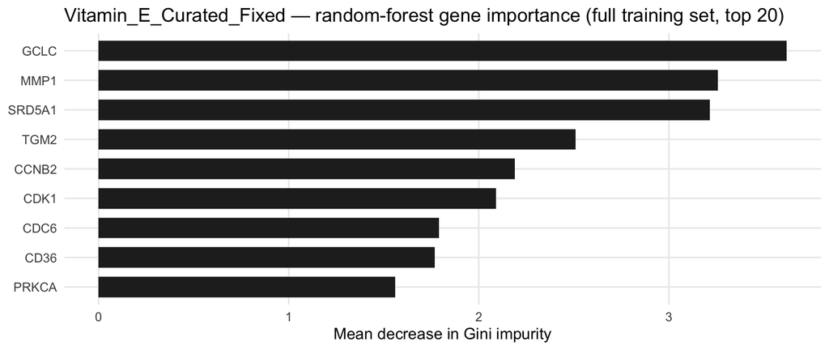

## Vitamin_E_GWAS

*Source:* Candidate — GWAS Catalog EFO_0007898 + EFO_0004738; protein-coding mapped genes of 5 associations with p <= 5e-08

*Panel:* Vitamin E · *Training set:* GSE110747 liver · mouse vitamin E diet · *Signature size:* 5 genes · *Score direction learned in training:* GSVA lower in case; ssGSEA lower in case; PLAGE lower in case; zScore lower in case; singscore lower in case

| Dataset | Species | Signature genes | Found in data | Coverage |
| --- | --- | --- | --- | --- |
| GSE110747 liver · mouse vitamin E diet | Mus musculus | 5 | 4 | 80% |
| GSE1063 · rat vitamin E-deficient diet | Rattus norvegicus | 5 | 0 | 0% |
| GSE8150 brain · aged mouse tocopherol | Mus musculus | 5 | 5 | 100% |
| GSE8146 heart · aged mouse tocopherol | Mus musculus | 5 | 2 | 40% |
| GSE195619 HepaRG · human oleic acid ± vitamin E | Homo sapiens | 5 | 5 | 100% |

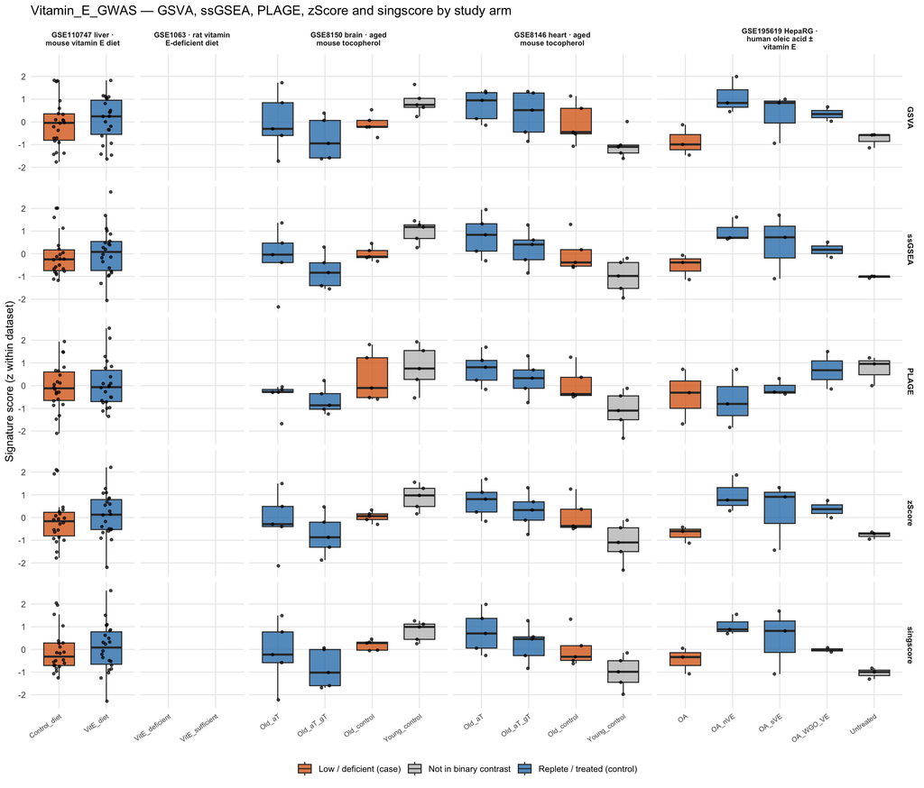

**ANOVA p-values.** *All arms* = one-way ANOVA across every study arm; *case vs control* = group effect after the listed covariates.

| Dataset | Role | Adjusted for | p (all arms) / p (case vs control) GSVA | p (all arms) / p (case vs control) ssGSEA | p (all arms) / p (case vs control) PLAGE | p (all arms) / p (case vs control) zScore | p (all arms) / p (case vs control) singscore |
| --- | --- | --- | --- | --- | --- | --- | --- |
| GSE110747 liver · mouse vitamin E diet | Training | exercise | 0.575 / 0.578 | 0.650 / 0.641 | 0.722 / 0.723 | 0.509 / 0.514 | 0.715 / 0.709 |
| GSE1063 · rat vitamin E-deficient diet | External | — | — / — | — / — | — / — | — / — | — / — |
| GSE8150 brain · aged mouse tocopherol | External | — | 0.074 / 0.627 | 0.032 / 0.363 | 0.050 / 0.048 | 0.056 / 0.355 | 0.050 / 0.215 |
| GSE8146 heart · aged mouse tocopherol | External | — | 0.022 / 0.217 | 0.023 / 0.281 | 0.012 / 0.292 | 0.012 / 0.292 | 0.023 / 0.310 |
| GSE195619 HepaRG · human oleic acid ± vitamin E | External | — | 0.049 / 0.025 | 0.072 / 0.082 | 0.406 / 0.672 | 0.129 / 0.063 | 0.060 / 0.110 |

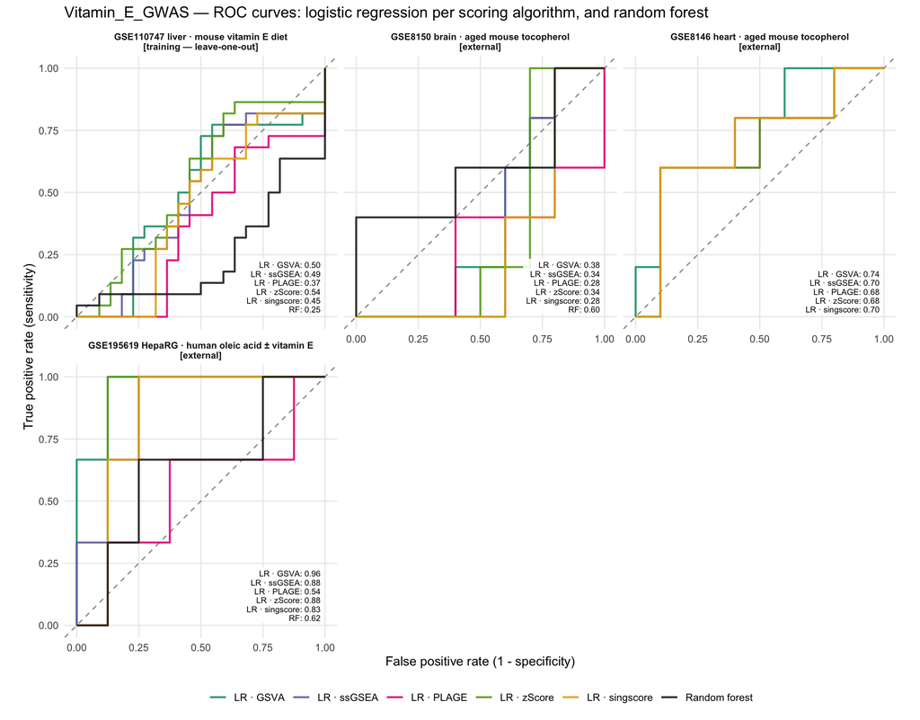

| Dataset | Validation | Model | AUC | 95% CI | Accuracy (p ≥ 0.5) | n case | n control |
| --- | --- | --- | --- | --- | --- | --- | --- |
| GSE110747 liver · mouse vitamin E diet | Internal (in-sample) | Score · GSVA | 0.57 | 0.39–0.75 | — | 22 | 22 |
|  |  | Score · ssGSEA | 0.56 | 0.38–0.73 | — | 22 | 22 |
|  |  | Score · PLAGE | 0.51 | 0.33–0.68 | — | 22 | 22 |
|  |  | Score · zScore | 0.60 | 0.42–0.77 | — | 22 | 22 |
|  |  | Score · singscore | 0.55 | 0.38–0.73 | — | 22 | 22 |
|  | Internal (LOOCV) | LR · GSVA | 0.50 | 0.32–0.68 | 0.52 | 22 | 22 |
|  |  | LR · ssGSEA | 0.49 | 0.31–0.67 | 0.55 | 22 | 22 |
|  |  | LR · PLAGE | 0.37 | 0.20–0.54 | 0.45 | 22 | 22 |
|  |  | LR · zScore | 0.54 | 0.36–0.72 | 0.59 | 22 | 22 |
|  |  | LR · singscore | 0.45 | 0.27–0.63 | 0.55 | 22 | 22 |
|  |  | Random forest | 0.25 | 0.10–0.40 | 0.3 | 22 | 22 |
|  | Internal (leave-pair-out) | LR · GSVA | 0.57 | — | — | 22 | 22 |
|  |  | LR · ssGSEA | 0.55 | — | — | 22 | 22 |
|  |  | LR · PLAGE | 0.45 | — | — | 22 | 22 |
|  |  | LR · zScore | 0.60 | — | — | 22 | 22 |
|  |  | LR · singscore | 0.52 | — | — | 22 | 22 |
|  |  | Random forest | 0.28 | — | — | 22 | 22 |
| GSE8150 brain · aged mouse tocopherol | External | Score · GSVA | 0.38 | 0.09–0.67 | — | 5 | 10 |
|  |  | Score · ssGSEA | 0.34 | 0.05–0.63 | — | 5 | 10 |
|  |  | Score · PLAGE | 0.28 | 0.00–0.59 | — | 5 | 10 |
|  |  | Score · zScore | 0.34 | 0.04–0.64 | — | 5 | 10 |
|  |  | Score · singscore | 0.28 | 0.01–0.55 | — | 5 | 10 |
|  |  | LR · GSVA | 0.38 | 0.09–0.67 | 0.33 | 5 | 10 |
|  |  | LR · ssGSEA | 0.34 | 0.05–0.63 | 0.33 | 5 | 10 |
|  |  | LR · PLAGE | 0.28 | 0.00–0.59 | 0.33 | 5 | 10 |
|  |  | LR · zScore | 0.34 | 0.04–0.64 | 0.4 | 5 | 10 |
|  |  | LR · singscore | 0.28 | 0.01–0.55 | 0.33 | 5 | 10 |
|  |  | Random forest | 0.60 | 0.22–0.98 | 0.6 | 5 | 10 |
| GSE8146 heart · aged mouse tocopherol |  | Score · GSVA | 0.74 | 0.45–1.00 | — | 5 | 10 |
|  |  | Score · ssGSEA | 0.70 | 0.38–1.00 | — | 5 | 10 |
|  |  | Score · PLAGE | 0.68 | 0.35–1.00 | — | 5 | 10 |
|  |  | Score · zScore | 0.68 | 0.35–1.00 | — | 5 | 10 |
|  |  | Score · singscore | 0.70 | 0.38–1.00 | — | 5 | 10 |
|  |  | LR · GSVA | 0.74 | 0.45–1.00 | 0.6 | 5 | 10 |
|  |  | LR · ssGSEA | 0.70 | 0.38–1.00 | 0.67 | 5 | 10 |
|  |  | LR · PLAGE | 0.68 | 0.35–1.00 | 0.53 | 5 | 10 |
|  |  | LR · zScore | 0.68 | 0.35–1.00 | 0.53 | 5 | 10 |
|  |  | LR · singscore | 0.70 | 0.38–1.00 | 0.67 | 5 | 10 |
| GSE195619 HepaRG · human oleic acid ± vitamin E |  | Score · GSVA | 0.96 | 0.84–1.00 | — | 3 | 8 |
|  |  | Score · ssGSEA | 0.88 | 0.65–1.00 | — | 3 | 8 |
|  |  | Score · PLAGE | 0.54 | 0.06–1.00 | — | 3 | 8 |
|  |  | Score · zScore | 0.88 | 0.63–1.00 | — | 3 | 8 |
|  |  | Score · singscore | 0.83 | 0.57–1.00 | — | 3 | 8 |
|  |  | LR · GSVA | 0.96 | 0.84–1.00 | 0.82 | 3 | 8 |
|  |  | LR · ssGSEA | 0.88 | 0.65–1.00 | 0.82 | 3 | 8 |
|  |  | LR · PLAGE | 0.54 | 0.06–1.00 | 0.55 | 3 | 8 |
|  |  | LR · zScore | 0.88 | 0.63–1.00 | 0.82 | 3 | 8 |
|  |  | LR · singscore | 0.83 | 0.57–1.00 | 0.73 | 3 | 8 |
|  |  | Random forest | 0.62 | 0.19–1.00 | 0.45 | 3 | 8 |

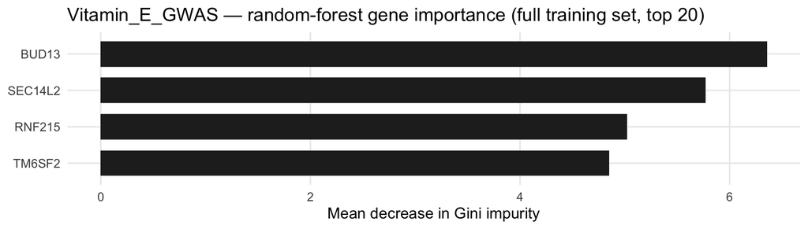

# Carnitine

## Carnitine_Mito

*Source:* Curated (Signatures/NutSignaturesList.R)

*Panel:* Carnitine · *Training set:* GSE343742 BMM · mouse L-carnitine ± LPS · *Signature size:* 5 genes · *Score direction learned in training:* GSVA lower in case; ssGSEA lower in case; PLAGE lower in case; zScore lower in case; singscore lower in case

| Dataset | Species | Signature genes | Found in data | Coverage |
| --- | --- | --- | --- | --- |
| GSE343742 BMM · mouse L-carnitine ± LPS | Mus musculus | 5 | 4 | 80% |
| GSE344237 liver · mouse resveratrol + L-carnitine | Mus musculus | 5 | 5 | 100% |

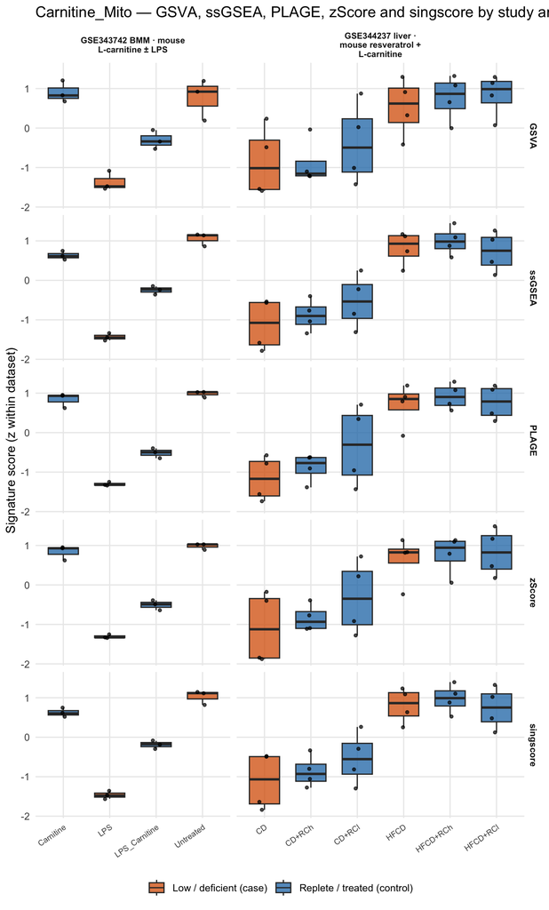

**ANOVA p-values.** *All arms* = one-way ANOVA across every study arm; *case vs control* = group effect after the listed covariates.

| Dataset | Role | Adjusted for | p (all arms) / p (case vs control) GSVA | p (all arms) / p (case vs control) ssGSEA | p (all arms) / p (case vs control) PLAGE | p (all arms) / p (case vs control) zScore | p (all arms) / p (case vs control) singscore |
| --- | --- | --- | --- | --- | --- | --- | --- |
| GSE343742 BMM · mouse L-carnitine ± LPS | Training | lps | 1.2e-04 / 0.035 | 3.2e-08 / 0.204 | 3.1e-08 / 0.089 | 3.2e-08 / 0.089 | 5.1e-08 / 0.167 |
| GSE344237 liver · mouse resveratrol + L-carnitine | External | diet | 0.007 / 0.449 | 1.7e-05 / 0.320 | 1.4e-04 / 0.189 | 0.002 / 0.263 | 3.2e-05 / 0.321 |

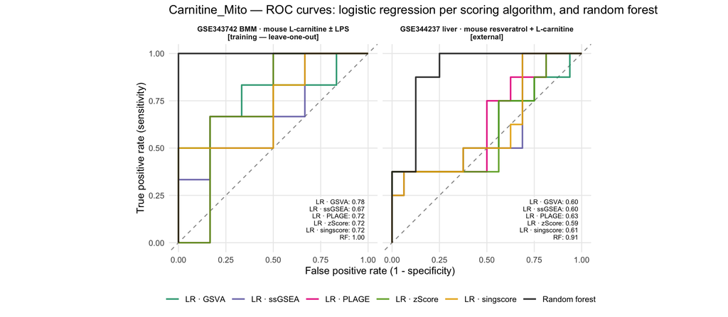

| Dataset | Validation | Model | AUC | 95% CI | Accuracy (p ≥ 0.5) | n case | n control |
| --- | --- | --- | --- | --- | --- | --- | --- |
| GSE343742 BMM · mouse L-carnitine ± LPS | Internal (in-sample) | Score · GSVA | 0.86 | 0.64–1.00 | — | 6 | 6 |
|  |  | Score · ssGSEA | 0.75 | 0.44–1.00 | — | 6 | 6 |
|  |  | Score · PLAGE | 0.81 | 0.54–1.00 | — | 6 | 6 |
|  |  | Score · zScore | 0.81 | 0.54–1.00 | — | 6 | 6 |
|  |  | Score · singscore | 0.75 | 0.44–1.00 | — | 6 | 6 |
|  | Internal (LOOCV) | LR · GSVA | 0.78 | 0.48–1.00 | 0.67 | 6 | 6 |
|  |  | LR · ssGSEA | 0.67 | 0.33–1.00 | 0.5 | 6 | 6 |
|  |  | LR · PLAGE | 0.72 | 0.38–1.00 | 0.75 | 6 | 6 |
|  |  | LR · zScore | 0.72 | 0.38–1.00 | 0.75 | 6 | 6 |
|  |  | LR · singscore | 0.72 | 0.40–1.00 | 0.5 | 6 | 6 |
|  |  | Random forest | 1.00 | 1.00–1.00 | 0.92 | 6 | 6 |
|  | Internal (leave-pair-out) | LR · GSVA | 0.86 | — | — | 6 | 6 |
|  |  | LR · ssGSEA | 0.75 | — | — | 6 | 6 |
|  |  | LR · PLAGE | 0.81 | — | — | 6 | 6 |
|  |  | LR · zScore | 0.81 | — | — | 6 | 6 |
|  |  | LR · singscore | 0.75 | — | — | 6 | 6 |
|  |  | Random forest | 0.97 | — | — | 6 | 6 |
| GSE344237 liver · mouse resveratrol + L-carnitine | External | Score · GSVA | 0.60 | 0.32–0.88 | — | 8 | 16 |
|  |  | Score · ssGSEA | 0.60 | 0.33–0.87 | — | 8 | 16 |
|  |  | Score · PLAGE | 0.63 | 0.37–0.89 | — | 8 | 16 |
|  |  | Score · zScore | 0.59 | 0.32–0.87 | — | 8 | 16 |
|  |  | Score · singscore | 0.61 | 0.35–0.87 | — | 8 | 16 |
|  |  | LR · GSVA | 0.60 | 0.32–0.88 | 0.5 | 8 | 16 |
|  |  | LR · ssGSEA | 0.60 | 0.33–0.87 | 0.54 | 8 | 16 |
|  |  | LR · PLAGE | 0.63 | 0.37–0.89 | 0.5 | 8 | 16 |
|  |  | LR · zScore | 0.59 | 0.32–0.87 | 0.46 | 8 | 16 |
|  |  | LR · singscore | 0.61 | 0.35–0.87 | 0.58 | 8 | 16 |
|  |  | Random forest | 0.91 | 0.79–1.00 | 0.83 | 8 | 16 |

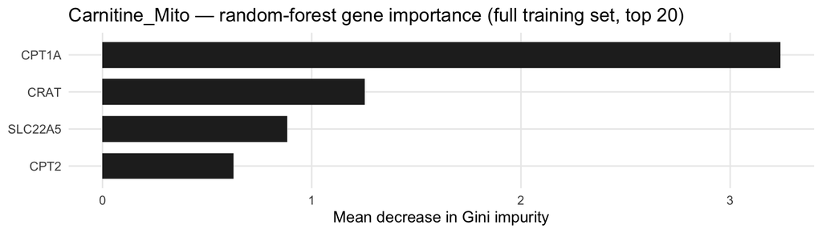

## Carnitine_GWAS

*Source:* Candidate — GWAS Catalog EFO_0010469; protein-coding mapped genes of 199 associations with p <= 5e-08

*Panel:* Carnitine · *Training set:* GSE343742 BMM · mouse L-carnitine ± LPS · *Signature size:* 48 genes · *Score direction learned in training:* GSVA higher in case; ssGSEA higher in case; PLAGE lower in case; zScore lower in case; singscore lower in case

| Dataset | Species | Signature genes | Found in data | Coverage |
| --- | --- | --- | --- | --- |
| GSE343742 BMM · mouse L-carnitine ± LPS | Mus musculus | 48 | 44 | 92% |
| GSE344237 liver · mouse resveratrol + L-carnitine | Mus musculus | 48 | 46 | 96% |

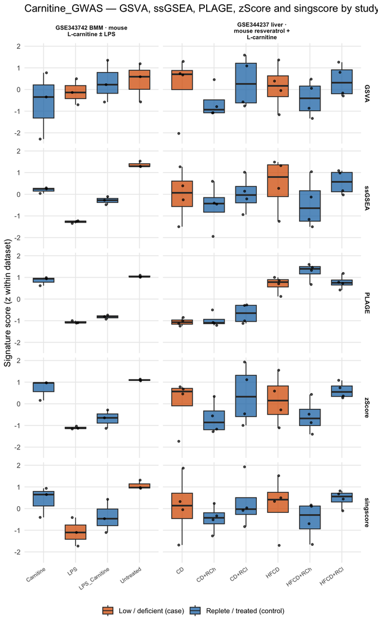

**ANOVA p-values.** *All arms* = one-way ANOVA across every study arm; *case vs control* = group effect after the listed covariates.

| Dataset | Role | Adjusted for | p (all arms) / p (case vs control) GSVA | p (all arms) / p (case vs control) ssGSEA | p (all arms) / p (case vs control) PLAGE | p (all arms) / p (case vs control) zScore | p (all arms) / p (case vs control) singscore |
| --- | --- | --- | --- | --- | --- | --- | --- |
| GSE343742 BMM · mouse L-carnitine ± LPS | Training | lps | 0.635 / 0.656 | 9.5e-08 / 0.806 | 2.3e-08 / 0.834 | 7.1e-05 / 0.965 | 0.014 / 0.981 |
| GSE344237 liver · mouse resveratrol + L-carnitine | External | diet | 0.666 / 0.618 | 0.586 / 0.466 | 1.9e-08 / 0.087 | 0.390 / 0.699 | 0.709 / 0.652 |

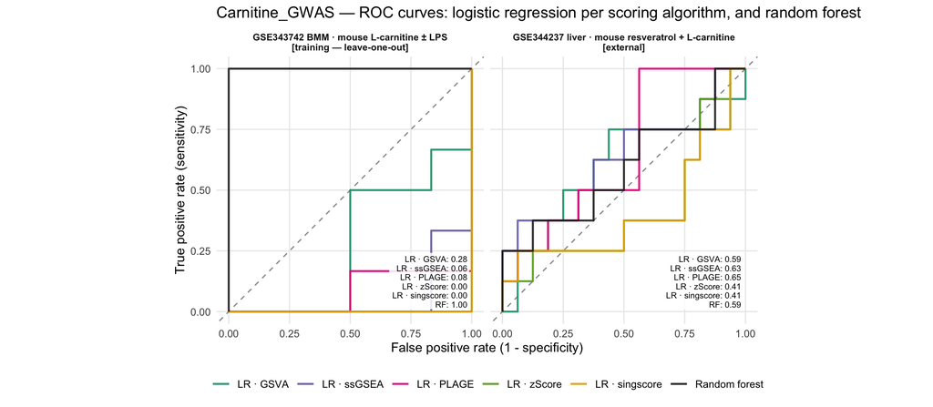

| Dataset | Validation | Model | AUC | 95% CI | Accuracy (p ≥ 0.5) | n case | n control |
| --- | --- | --- | --- | --- | --- | --- | --- |
| GSE343742 BMM · mouse L-carnitine ± LPS | Internal (in-sample) | Score · GSVA | 0.53 | 0.16–0.89 | — | 6 | 6 |
|  |  | Score · ssGSEA | 0.61 | 0.26–0.96 | — | 6 | 6 |
|  |  | Score · PLAGE | 0.56 | 0.18–0.93 | — | 6 | 6 |
|  |  | Score · zScore | 0.53 | 0.15–0.90 | — | 6 | 6 |
|  |  | Score · singscore | 0.42 | 0.05–0.78 | — | 6 | 6 |
|  | Internal (LOOCV) | LR · GSVA | 0.28 | 0.00–0.60 | 0.42 | 6 | 6 |
|  |  | LR · ssGSEA | 0.06 | 0.00–0.18 | 0.25 | 6 | 6 |
|  |  | LR · PLAGE | 0.08 | 0.00–0.26 | 0.25 | 6 | 6 |
|  |  | LR · zScore | 0.00 | 0.00–0.00 | 0 | 6 | 6 |
|  |  | LR · singscore | 0.00 | 0.00–0.00 | 0 | 6 | 6 |
|  |  | Random forest | 1.00 | 1.00–1.00 | 1 | 6 | 6 |
|  | Internal (leave-pair-out) | LR · GSVA | 0.39 | — | — | 6 | 6 |
|  |  | LR · ssGSEA | 0.36 | — | — | 6 | 6 |
|  |  | LR · PLAGE | 0.19 | — | — | 6 | 6 |
|  |  | LR · zScore | 0.08 | — | — | 6 | 6 |
|  |  | LR · singscore | 0.03 | — | — | 6 | 6 |
|  |  | Random forest | 1.00 | — | — | 6 | 6 |
| GSE344237 liver · mouse resveratrol + L-carnitine | External | Score · GSVA | 0.59 | 0.30–0.87 | — | 8 | 16 |
|  |  | Score · ssGSEA | 0.63 | 0.37–0.90 | — | 8 | 16 |
|  |  | Score · PLAGE | 0.65 | 0.41–0.88 | — | 8 | 16 |
|  |  | Score · zScore | 0.41 | 0.14–0.69 | — | 8 | 16 |
|  |  | Score · singscore | 0.41 | 0.12–0.69 | — | 8 | 16 |
|  |  | LR · GSVA | 0.59 | 0.30–0.87 | 0.58 | 8 | 16 |
|  |  | LR · ssGSEA | 0.63 | 0.37–0.90 | 0.62 | 8 | 16 |
|  |  | LR · PLAGE | 0.65 | 0.41–0.88 | 0.54 | 8 | 16 |
|  |  | LR · zScore | 0.41 | 0.14–0.69 | 0.46 | 8 | 16 |
|  |  | LR · singscore | 0.41 | 0.12–0.69 | 0.46 | 8 | 16 |
|  |  | Random forest | 0.59 | 0.31–0.86 | 0.54 | 8 | 16 |

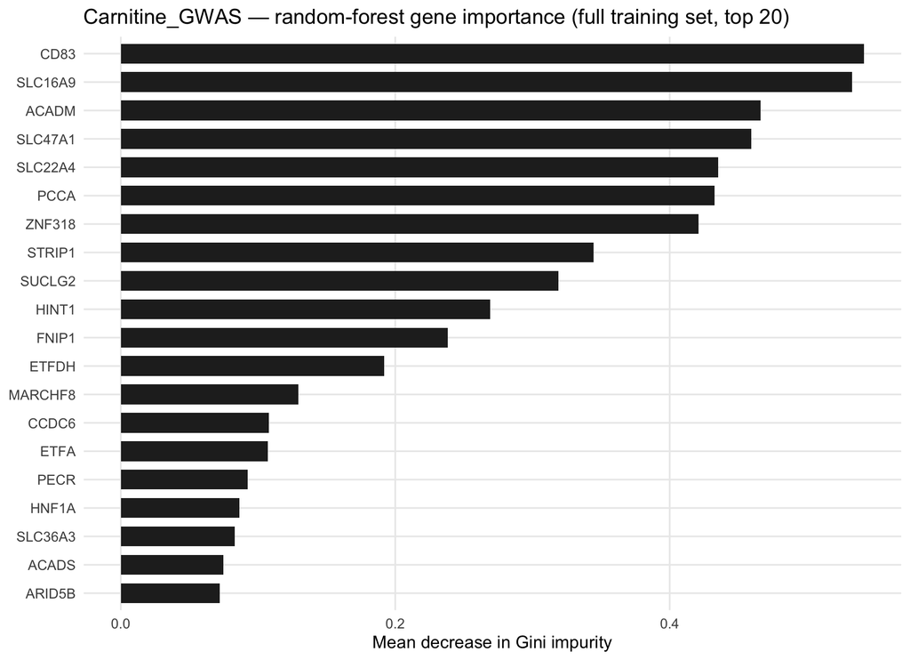

# Vitamin K

## Vitamin_K

*Source:* Curated (Signatures/NutSignaturesList.R)

*Panel:* Vitamin K · *Training set:* GSE148011 MEF · mouse vitamin K precursor · *Signature size:* 25 genes · *Score direction learned in training:* GSVA lower in case; ssGSEA lower in case; PLAGE lower in case; zScore lower in case; singscore lower in case

| Dataset | Species | Signature genes | Found in data | Coverage |
| --- | --- | --- | --- | --- |
| GSE148011 MEF · mouse vitamin K precursor | Mus musculus | 25 | 24 | 96% |
| GSE267133 ARPE-19 · human vitamin K1 (+ erastin) | Homo sapiens | 25 | 23 | 92% |
| GSE237219 Jurkat · human vitamin K1 | Homo sapiens | 25 | 24 | 96% |
| GSE272401 BMDM · mouse RANKL ± vitamins D+K | Mus musculus | 25 | 21 | 84% |

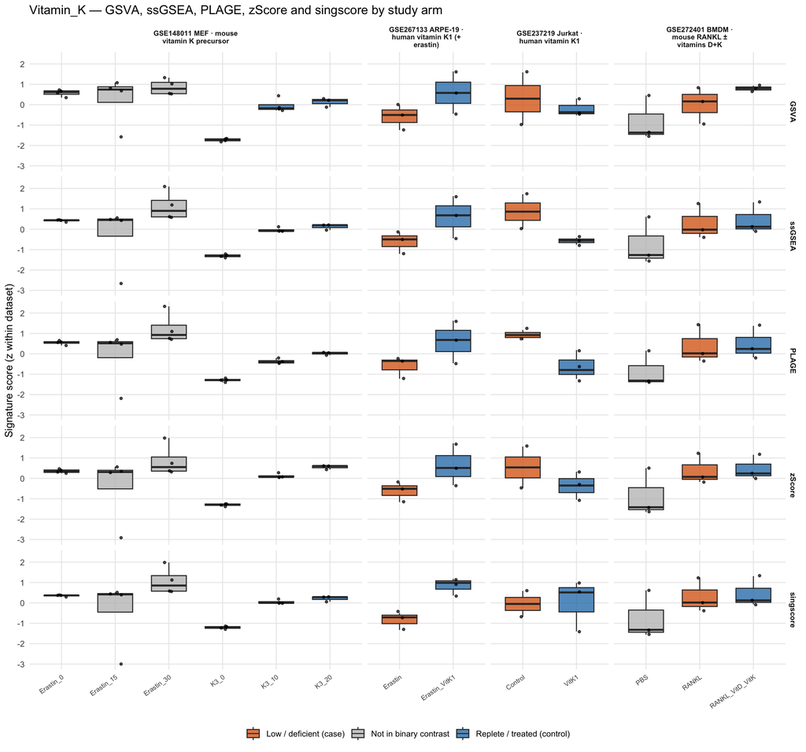

**ANOVA p-values.** *All arms* = one-way ANOVA across every study arm; *case vs control* = group effect after the listed covariates.

| Dataset | Role | Adjusted for | p (all arms) / p (case vs control) GSVA | p (all arms) / p (case vs control) ssGSEA | p (all arms) / p (case vs control) PLAGE | p (all arms) / p (case vs control) zScore | p (all arms) / p (case vs control) singscore |
| --- | --- | --- | --- | --- | --- | --- | --- |
| GSE148011 MEF · mouse vitamin K precursor | Training | — | 1.2e-04 / 7.8e-07 | 0.006 / 3.1e-08 | 0.002 / 8.9e-06 | 0.014 / 6.6e-07 | 0.017 / 2.8e-08 |
| GSE267133 ARPE-19 · human vitamin K1 (+ erastin) | External | — | 0.168 / 0.168 | 0.140 / 0.140 | 0.144 / 0.144 | 0.127 / 0.127 | 0.009 / 0.009 |
| GSE237219 Jurkat · human vitamin K1 | External | — | 0.661 / 0.661 | 0.113 / 0.113 | 0.075 / 0.075 | 0.402 / 0.402 | 0.942 / 0.942 |
| GSE272401 BMDM · mouse RANKL ± vitamins D+K | External | — | 0.135 / 0.219 | 0.321 / 0.821 | 0.195 / 0.901 | 0.202 / 0.888 | 0.309 / 0.823 |

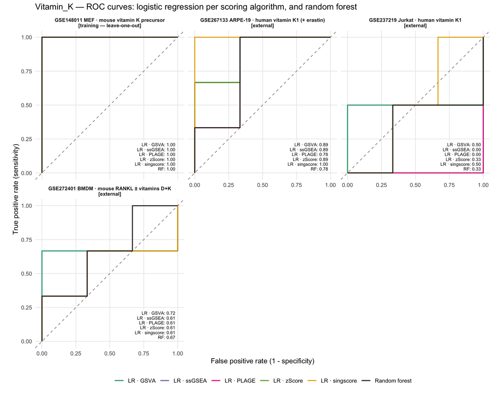

| Dataset | Validation | Model | AUC | 95% CI | Accuracy (p ≥ 0.5) | n case | n control |
| --- | --- | --- | --- | --- | --- | --- | --- |
| GSE148011 MEF · mouse vitamin K precursor | Internal (in-sample) | Score · GSVA | 1.00 | 1.00–1.00 | — | 4 | 7 |
|  |  | Score · ssGSEA | 1.00 | 1.00–1.00 | — | 4 | 7 |
|  |  | Score · PLAGE | 1.00 | 1.00–1.00 | — | 4 | 7 |
|  |  | Score · zScore | 1.00 | 1.00–1.00 | — | 4 | 7 |
|  |  | Score · singscore | 1.00 | 1.00–1.00 | — | 4 | 7 |
|  | Internal (LOOCV) | LR · GSVA | 1.00 | 1.00–1.00 | 1 | 4 | 7 |
|  |  | LR · ssGSEA | 1.00 | 1.00–1.00 | 1 | 4 | 7 |
|  |  | LR · PLAGE | 1.00 | 1.00–1.00 | 1 | 4 | 7 |
|  |  | LR · zScore | 1.00 | 1.00–1.00 | 1 | 4 | 7 |
|  |  | LR · singscore | 1.00 | 1.00–1.00 | 1 | 4 | 7 |
|  |  | Random forest | 1.00 | 1.00–1.00 | 1 | 4 | 7 |
|  | Internal (leave-pair-out) | LR · GSVA | 1.00 | — | — | 4 | 7 |
|  |  | LR · ssGSEA | 1.00 | — | — | 4 | 7 |
|  |  | LR · PLAGE | 1.00 | — | — | 4 | 7 |
|  |  | LR · zScore | 1.00 | — | — | 4 | 7 |
|  |  | LR · singscore | 1.00 | — | — | 4 | 7 |
|  |  | Random forest | 1.00 | — | — | 4 | 7 |
| GSE267133 ARPE-19 · human vitamin K1 (+ erastin) | External | Score · GSVA | 0.89 | 0.58–1.00 | — | 3 | 3 |
|  |  | Score · ssGSEA | 0.89 | 0.58–1.00 | — | 3 | 3 |
|  |  | Score · PLAGE | 0.78 | 0.29–1.00 | — | 3 | 3 |
|  |  | Score · zScore | 0.89 | 0.58–1.00 | — | 3 | 3 |
|  |  | Score · singscore | 1.00 | 1.00–1.00 | — | 3 | 3 |
|  |  | LR · GSVA | 0.89 | 0.58–1.00 | 0.67 | 3 | 3 |
|  |  | LR · ssGSEA | 0.89 | 0.58–1.00 | 0.67 | 3 | 3 |
|  |  | LR · PLAGE | 0.78 | 0.29–1.00 | 0.5 | 3 | 3 |
|  |  | LR · zScore | 0.89 | 0.58–1.00 | 0.83 | 3 | 3 |
|  |  | LR · singscore | 1.00 | 1.00–1.00 | 1 | 3 | 3 |
|  |  | Random forest | 0.78 | 0.29–1.00 | 0.5 | 3 | 3 |
| GSE237219 Jurkat · human vitamin K1 |  | Score · GSVA | 0.50 | 0.00–1.00 | — | 2 | 3 |
|  |  | Score · ssGSEA | 0.00 | 0.00–0.00 | — | 2 | 3 |
|  |  | Score · PLAGE | 0.00 | 0.00–0.00 | — | 2 | 3 |
|  |  | Score · zScore | 0.33 | 0.00–1.00 | — | 2 | 3 |
|  |  | Score · singscore | 0.50 | 0.00–1.00 | — | 2 | 3 |
|  |  | LR · GSVA | 0.50 | 0.00–1.00 | 0.6 | 2 | 3 |
|  |  | LR · ssGSEA | 0.00 | 0.00–0.00 | 0 | 2 | 3 |
|  |  | LR · PLAGE | 0.00 | 0.00–0.00 | 0.2 | 2 | 3 |
|  |  | LR · zScore | 0.33 | 0.00–1.00 | 0.6 | 2 | 3 |
|  |  | LR · singscore | 0.50 | 0.00–1.00 | 0.6 | 2 | 3 |
|  |  | Random forest | 0.33 | 0.00–1.00 | 0.6 | 2 | 3 |
| GSE272401 BMDM · mouse RANKL ± vitamins D+K |  | Score · GSVA | 0.78 | 0.29–1.00 | — | 3 | 3 |
|  |  | Score · ssGSEA | 0.67 | 0.13–1.00 | — | 3 | 3 |
|  |  | Score · PLAGE | 0.56 | 0.00–1.00 | — | 3 | 3 |
|  |  | Score · zScore | 0.56 | 0.00–1.00 | — | 3 | 3 |
|  |  | Score · singscore | 0.67 | 0.13–1.00 | — | 3 | 3 |
|  |  | LR · GSVA | 0.72 | 0.17–1.00 | 0.67 | 3 | 3 |
|  |  | LR · ssGSEA | 0.61 | 0.06–1.00 | 0.5 | 3 | 3 |
|  |  | LR · PLAGE | 0.61 | 0.06–1.00 | 0.67 | 3 | 3 |
|  |  | LR · zScore | 0.61 | 0.06–1.00 | 0.67 | 3 | 3 |
|  |  | LR · singscore | 0.61 | 0.06–1.00 | 0.5 | 3 | 3 |
|  |  | Random forest | 0.67 | 0.13–1.00 | 0.5 | 3 | 3 |

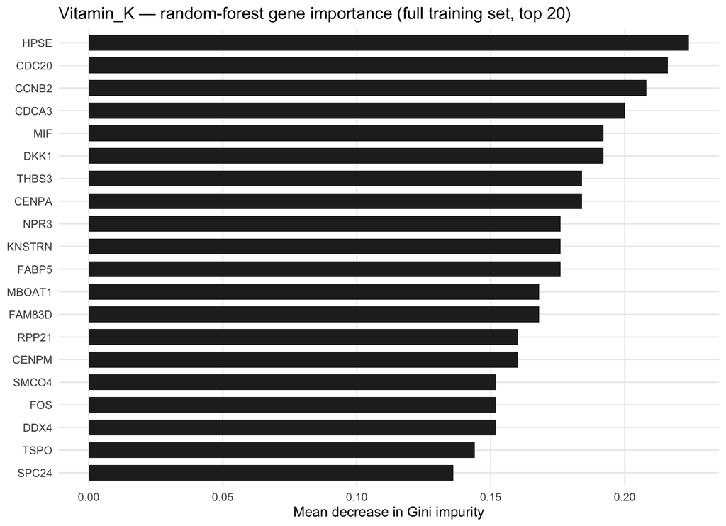

## Vitamin_K_GSE148011_Down

*Source:* Candidate — GSE148011 vitamin K arm; limma-trend, vitamin K precursor 10/20 uM (n=7) vs 0 uM (n=4), FDR<0.1 (no gene reaches 2-fold), top 25 by p - lower with vitamin K

*Panel:* Vitamin K · *Training set:* GSE148011 MEF · mouse vitamin K precursor · *Signature size:* 14 genes · *Score direction learned in training:* GSVA higher in case; ssGSEA higher in case; PLAGE higher in case; zScore higher in case; singscore higher in case

| Dataset | Species | Signature genes | Found in data | Coverage |
| --- | --- | --- | --- | --- |
| GSE148011 MEF · mouse vitamin K precursor | Mus musculus | 14 | 14 | 100% |
| GSE267133 ARPE-19 · human vitamin K1 (+ erastin) | Homo sapiens | 14 | 14 | 100% |
| GSE237219 Jurkat · human vitamin K1 | Homo sapiens | 14 | 14 | 100% |
| GSE272401 BMDM · mouse RANKL ± vitamins D+K | Mus musculus | 14 | 13 | 93% |

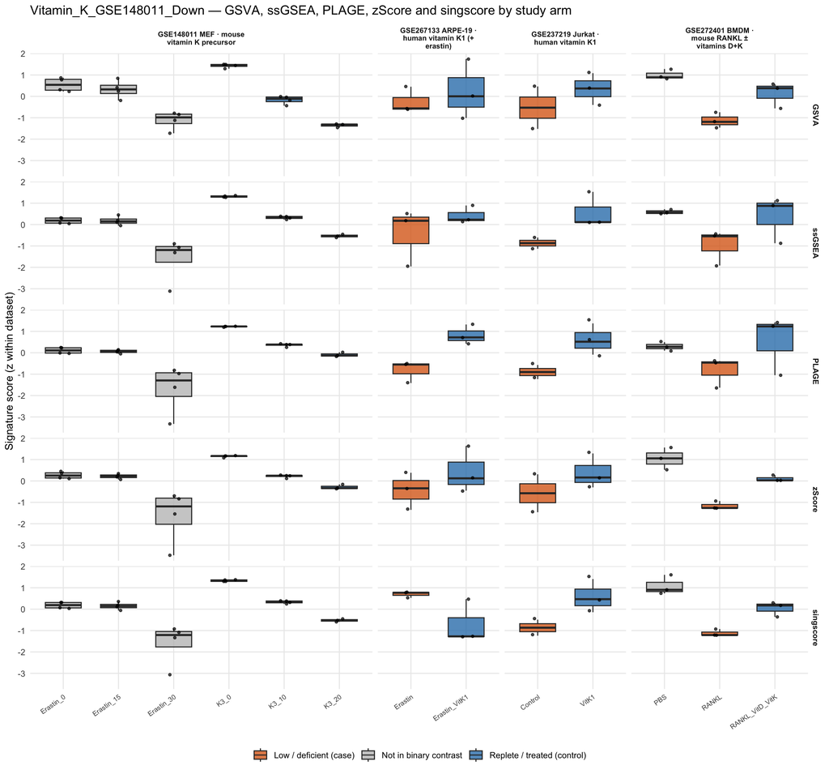

**ANOVA p-values.** *All arms* = one-way ANOVA across every study arm; *case vs control* = group effect after the listed covariates.

| Dataset | Role | Adjusted for | p (all arms) / p (case vs control) GSVA | p (all arms) / p (case vs control) ssGSEA | p (all arms) / p (case vs control) PLAGE | p (all arms) / p (case vs control) zScore | p (all arms) / p (case vs control) singscore |
| --- | --- | --- | --- | --- | --- | --- | --- |
| GSE148011 MEF · mouse vitamin K precursor | Training | — | 3.8e-09 / 1.4e-04 | 2.2e-06 / 3.0e-04 | 1.1e-05 / 2.1e-05 | 6.2e-05 / 2.6e-05 | 1.2e-06 / 2.7e-04 |
| GSE267133 ARPE-19 · human vitamin K1 (+ erastin) | External | — | 0.603 / 0.603 | 0.357 / 0.357 | 0.015 / 0.015 | 0.337 / 0.337 | 0.077 / 0.077 |
| GSE237219 Jurkat · human vitamin K1 | External | — | 0.411 / 0.411 | 0.110 / 0.110 | 0.087 / 0.087 | 0.365 / 0.365 | 0.111 / 0.111 |
| GSE272401 BMDM · mouse RANKL ± vitamins D+K | External | — | 0.003 / 0.036 | 0.104 / 0.165 | 0.220 / 0.201 | 5.4e-04 / 7.7e-04 | 7.3e-04 / 0.007 |

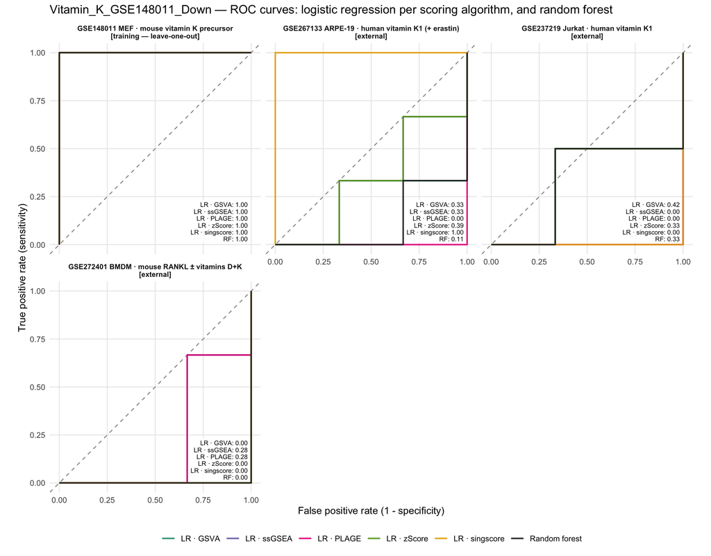

| Dataset | Validation | Model | AUC | 95% CI | Accuracy (p ≥ 0.5) | n case | n control |
| --- | --- | --- | --- | --- | --- | --- | --- |
| GSE148011 MEF · mouse vitamin K precursor | Internal (in-sample) | Score · GSVA | 1.00 | 1.00–1.00 | — | 4 | 7 |
|  |  | Score · ssGSEA | 1.00 | 1.00–1.00 | — | 4 | 7 |
|  |  | Score · PLAGE | 1.00 | 1.00–1.00 | — | 4 | 7 |
|  |  | Score · zScore | 1.00 | 1.00–1.00 | — | 4 | 7 |
|  |  | Score · singscore | 1.00 | 1.00–1.00 | — | 4 | 7 |
|  | Internal (LOOCV) | LR · GSVA | 1.00 | 1.00–1.00 | 1 | 4 | 7 |
|  |  | LR · ssGSEA | 1.00 | 1.00–1.00 | 1 | 4 | 7 |
|  |  | LR · PLAGE | 1.00 | 1.00–1.00 | 1 | 4 | 7 |
|  |  | LR · zScore | 1.00 | 1.00–1.00 | 1 | 4 | 7 |
|  |  | LR · singscore | 1.00 | 1.00–1.00 | 1 | 4 | 7 |
|  |  | Random forest | 1.00 | 1.00–1.00 | 1 | 4 | 7 |
|  | Internal (leave-pair-out) | LR · GSVA | 1.00 | — | — | 4 | 7 |
|  |  | LR · ssGSEA | 1.00 | — | — | 4 | 7 |
|  |  | LR · PLAGE | 1.00 | — | — | 4 | 7 |
|  |  | LR · zScore | 1.00 | — | — | 4 | 7 |
|  |  | LR · singscore | 1.00 | — | — | 4 | 7 |
|  |  | Random forest | 1.00 | — | — | 4 | 7 |
| GSE267133 ARPE-19 · human vitamin K1 (+ erastin) | External | Score · GSVA | 0.44 | 0.00–1.00 | — | 3 | 3 |
|  |  | Score · ssGSEA | 0.33 | 0.00–0.87 | — | 3 | 3 |
|  |  | Score · PLAGE | 0.00 | 0.00–0.00 | — | 3 | 3 |
|  |  | Score · zScore | 0.33 | 0.00–0.87 | — | 3 | 3 |
|  |  | Score · singscore | 1.00 | 1.00–1.00 | — | 3 | 3 |
|  |  | LR · GSVA | 0.33 | 0.00–0.83 | 0.33 | 3 | 3 |
|  |  | LR · ssGSEA | 0.33 | 0.00–0.87 | 0.5 | 3 | 3 |
|  |  | LR · PLAGE | 0.00 | 0.00–0.00 | 0.17 | 3 | 3 |
|  |  | LR · zScore | 0.39 | 0.00–0.94 | 0.33 | 3 | 3 |
|  |  | LR · singscore | 1.00 | 1.00–1.00 | 1 | 3 | 3 |
|  |  | Random forest | 0.11 | 0.00–0.42 | 0.33 | 3 | 3 |
| GSE237219 Jurkat · human vitamin K1 |  | Score · GSVA | 0.33 | 0.00–1.00 | — | 2 | 3 |
|  |  | Score · ssGSEA | 0.00 | 0.00–0.00 | — | 2 | 3 |
|  |  | Score · PLAGE | 0.00 | 0.00–0.00 | — | 2 | 3 |
|  |  | Score · zScore | 0.33 | 0.00–1.00 | — | 2 | 3 |
|  |  | Score · singscore | 0.00 | 0.00–0.00 | — | 2 | 3 |
|  |  | LR · GSVA | 0.42 | 0.00–1.00 | 0.6 | 2 | 3 |
|  |  | LR · ssGSEA | 0.00 | 0.00–0.00 | 0.4 | 2 | 3 |
|  |  | LR · PLAGE | 0.00 | 0.00–0.00 | 0.2 | 2 | 3 |
|  |  | LR · zScore | 0.33 | 0.00–1.00 | 0.4 | 2 | 3 |
|  |  | LR · singscore | 0.00 | 0.00–0.00 | 0.4 | 2 | 3 |
|  |  | Random forest | 0.33 | 0.00–1.00 | 0.4 | 2 | 3 |
| GSE272401 BMDM · mouse RANKL ± vitamins D+K |  | Score · GSVA | 0.00 | 0.00–0.00 | — | 3 | 3 |
|  |  | Score · ssGSEA | 0.22 | 0.00–0.71 | — | 3 | 3 |
|  |  | Score · PLAGE | 0.22 | 0.00–0.71 | — | 3 | 3 |
|  |  | Score · zScore | 0.00 | 0.00–0.00 | — | 3 | 3 |
|  |  | Score · singscore | 0.00 | 0.00–0.00 | — | 3 | 3 |
|  |  | LR · GSVA | 0.00 | 0.00–0.00 | 0.17 | 3 | 3 |
|  |  | LR · ssGSEA | 0.28 | 0.00–0.83 | 0.17 | 3 | 3 |
|  |  | LR · PLAGE | 0.28 | 0.00–0.83 | 0.17 | 3 | 3 |
|  |  | LR · zScore | 0.00 | 0.00–0.00 | 0 | 3 | 3 |
|  |  | LR · singscore | 0.00 | 0.00–0.00 | 0.17 | 3 | 3 |
|  |  | Random forest | 0.00 | 0.00–0.00 | 0.33 | 3 | 3 |

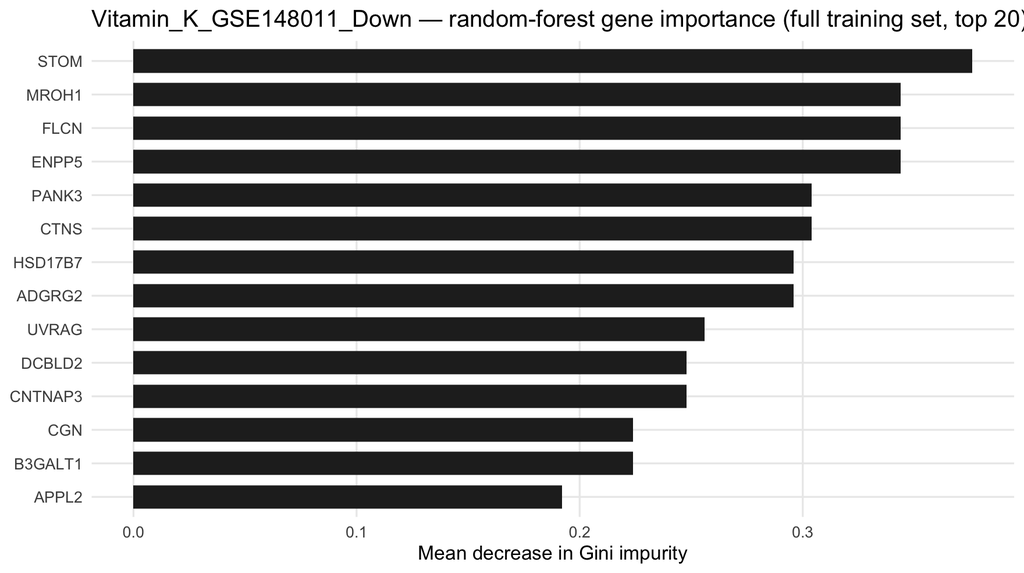

## Vitamin_K_GWAS

*Source:* Candidate — GWAS Catalog EFO_0004618; protein-coding mapped genes of 6 associations with p <= 1e-05

*Panel:* Vitamin K · *Training set:* GSE148011 MEF · mouse vitamin K precursor · *Signature size:* 7 genes · *Score direction learned in training:* GSVA higher in case; ssGSEA lower in case; PLAGE lower in case; zScore higher in case; singscore higher in case

| Dataset | Species | Signature genes | Found in data | Coverage |
| --- | --- | --- | --- | --- |
| GSE148011 MEF · mouse vitamin K precursor | Mus musculus | 7 | 6 | 86% |
| GSE267133 ARPE-19 · human vitamin K1 (+ erastin) | Homo sapiens | 7 | 4 | 57% |
| GSE237219 Jurkat · human vitamin K1 | Homo sapiens | 7 | 6 | 86% |
| GSE272401 BMDM · mouse RANKL ± vitamins D+K | Mus musculus | 7 | 6 | 86% |

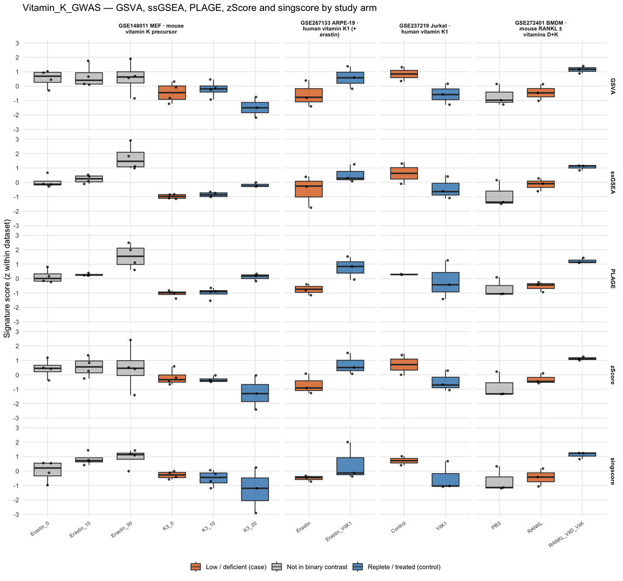

**ANOVA p-values.** *All arms* = one-way ANOVA across every study arm; *case vs control* = group effect after the listed covariates.

| Dataset | Role | Adjusted for | p (all arms) / p (case vs control) GSVA | p (all arms) / p (case vs control) ssGSEA | p (all arms) / p (case vs control) PLAGE | p (all arms) / p (case vs control) zScore | p (all arms) / p (case vs control) singscore |
| --- | --- | --- | --- | --- | --- | --- | --- |
| GSE148011 MEF · mouse vitamin K precursor | Training | — | 0.014 / 0.576 | 2.1e-06 / 0.072 | 4.0e-06 / 0.174 | 0.130 / 0.289 | 0.009 / 0.343 |
| GSE267133 ARPE-19 · human vitamin K1 (+ erastin) | External | — | 0.170 / 0.170 | 0.222 / 0.222 | 0.044 / 0.044 | 0.077 / 0.077 | 0.264 / 0.264 |
| GSE237219 Jurkat · human vitamin K1 | External | — | 0.129 / 0.129 | 0.314 / 0.314 | 0.672 / 0.672 | 0.237 / 0.237 | 0.229 / 0.229 |
| GSE272401 BMDM · mouse RANKL ± vitamins D+K | External | — | 0.014 / 0.012 | 0.020 / 0.013 | 0.004 / 0.002 | 0.014 / 0.003 | 0.027 / 0.016 |

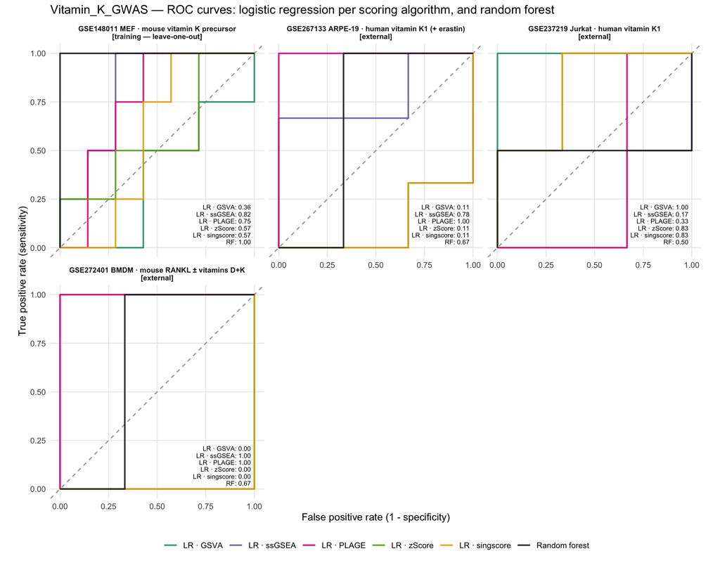

| Dataset | Validation | Model | AUC | 95% CI | Accuracy (p ≥ 0.5) | n case | n control |
| --- | --- | --- | --- | --- | --- | --- | --- |
| GSE148011 MEF · mouse vitamin K precursor | Internal (in-sample) | Score · GSVA | 0.61 | 0.22–0.99 | — | 4 | 7 |
|  |  | Score · ssGSEA | 0.86 | 0.61–1.00 | — | 4 | 7 |
|  |  | Score · PLAGE | 0.79 | 0.48–1.00 | — | 4 | 7 |
|  |  | Score · zScore | 0.61 | 0.22–1.00 | — | 4 | 7 |
|  |  | Score · singscore | 0.64 | 0.28–1.00 | — | 4 | 7 |
|  | Internal (LOOCV) | LR · GSVA | 0.36 | 0.00–0.73 | 0.55 | 4 | 7 |
|  |  | LR · ssGSEA | 0.82 | 0.55–1.00 | 0.64 | 4 | 7 |
|  |  | LR · PLAGE | 0.75 | 0.44–1.00 | 0.64 | 4 | 7 |
|  |  | LR · zScore | 0.57 | 0.16–0.99 | 0.55 | 4 | 7 |
|  |  | LR · singscore | 0.57 | 0.20–0.94 | 0.64 | 4 | 7 |
|  |  | Random forest | 1.00 | 1.00–1.00 | 0.82 | 4 | 7 |
|  | Internal (leave-pair-out) | LR · GSVA | 0.50 | — | — | 4 | 7 |
|  |  | LR · ssGSEA | 0.86 | — | — | 4 | 7 |
|  |  | LR · PLAGE | 0.79 | — | — | 4 | 7 |
|  |  | LR · zScore | 0.61 | — | — | 4 | 7 |
|  |  | LR · singscore | 0.64 | — | — | 4 | 7 |
|  |  | Random forest | 0.96 | — | — | 4 | 7 |
| GSE267133 ARPE-19 · human vitamin K1 (+ erastin) | External | Score · GSVA | 0.11 | 0.00–0.42 | — | 3 | 3 |
|  |  | Score · ssGSEA | 0.78 | 0.29–1.00 | — | 3 | 3 |
|  |  | Score · PLAGE | 1.00 | 1.00–1.00 | — | 3 | 3 |
|  |  | Score · zScore | 0.11 | 0.00–0.42 | — | 3 | 3 |
|  |  | Score · singscore | 0.11 | 0.00–0.42 | — | 3 | 3 |
|  |  | LR · GSVA | 0.11 | 0.00–0.42 | 0.33 | 3 | 3 |
|  |  | LR · ssGSEA | 0.78 | 0.29–1.00 | 0.67 | 3 | 3 |
|  |  | LR · PLAGE | 1.00 | 1.00–1.00 | 1 | 3 | 3 |
|  |  | LR · zScore | 0.11 | 0.00–0.42 | 0.17 | 3 | 3 |
|  |  | LR · singscore | 0.11 | 0.00–0.42 | 0.33 | 3 | 3 |
|  |  | Random forest | 0.67 | 0.01–1.00 | 0.33 | 3 | 3 |
| GSE237219 Jurkat · human vitamin K1 |  | Score · GSVA | 1.00 | 1.00–1.00 | — | 2 | 3 |
|  |  | Score · ssGSEA | 0.17 | 0.00–0.63 | — | 2 | 3 |
|  |  | Score · PLAGE | 0.33 | 0.00–0.99 | — | 2 | 3 |
|  |  | Score · zScore | 0.83 | 0.37–1.00 | — | 2 | 3 |
|  |  | Score · singscore | 0.83 | 0.37–1.00 | — | 2 | 3 |
|  |  | LR · GSVA | 1.00 | 1.00–1.00 | 0.8 | 2 | 3 |
|  |  | LR · ssGSEA | 0.17 | 0.00–0.63 | 0.2 | 2 | 3 |
|  |  | LR · PLAGE | 0.33 | 0.00–0.99 | 0.2 | 2 | 3 |
|  |  | LR · zScore | 0.83 | 0.37–1.00 | 0.6 | 2 | 3 |
|  |  | LR · singscore | 0.83 | 0.37–1.00 | 0.8 | 2 | 3 |
|  |  | Random forest | 0.50 | 0.00–1.00 | 0.6 | 2 | 3 |
| GSE272401 BMDM · mouse RANKL ± vitamins D+K |  | Score · GSVA | 0.00 | 0.00–0.00 | — | 3 | 3 |
|  |  | Score · ssGSEA | 1.00 | 1.00–1.00 | — | 3 | 3 |
|  |  | Score · PLAGE | 1.00 | 1.00–1.00 | — | 3 | 3 |
|  |  | Score · zScore | 0.00 | 0.00–0.00 | — | 3 | 3 |
|  |  | Score · singscore | 0.00 | 0.00–0.00 | — | 3 | 3 |
|  |  | LR · GSVA | 0.00 | 0.00–0.00 | 0 | 3 | 3 |
|  |  | LR · ssGSEA | 1.00 | 1.00–1.00 | 0.83 | 3 | 3 |
|  |  | LR · PLAGE | 1.00 | 1.00–1.00 | 1 | 3 | 3 |
|  |  | LR · zScore | 0.00 | 0.00–0.00 | 0 | 3 | 3 |
|  |  | LR · singscore | 0.00 | 0.00–0.00 | 0 | 3 | 3 |
|  |  | Random forest | 0.67 | 0.01–1.00 | 0.33 | 3 | 3 |

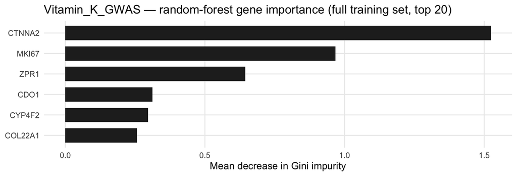